# Module 8

# Results

```r
library(rgbif)
library(tidyverse)
library(MuMIn)
library(rnoaa)
library(ggmap)
library(usmap)
library(magick)
```

```r
library(cowplot)
library(lme4)
library(car)
library(rsconnect)
library(curl)
library(data.table)
library(knitr)
library(rgdal)
#We set this code chunk to cache=TRUE, because the code took a significant amount of time to run, and we wanted to prevent having to run it over and over. Instead, the cache remembers the code unless we make a change!
species <- c("Progne subis","Piranga olivacea","Setophaga palmarum","Icterus galbula","Tyrannus tyrannus")
y <- paste0("2000",",","2019") #In the Additional Operations and Analyses section, we are asked to analyze our species from 2000-2019
m <- paste0("4",",","5") #In the Additional Operations and Analyses section, we are asked to analyze our species during April and May which correspond to the months 4 and 5
dat.l <-list()
for(s in species[4:5]){
n.obs <-  occ_data(scientificName = s,year=y,month=m,limit=0,country="US",basisOfRecord = "HUMAN_OBSERVATION",stateProvince="Massachusetts")$meta$count
print(n.obs)
dat.l[[paste0(s)]] <- occ_data(scientificName = s,year=y,month=m,
                               limit=n.obs,country="US",
                               basisOfRecord = "HUMAN_OBSERVATION",
                               stateProvince="Massachusetts")[[2]]
}
dat <- rbindlist(dat.l,fill=T)
head(dat)
saveRDS(dat,"massbird.data.RDS")
```

in this chunk above you had `saveRDS(data,"massbird.data.RDS)` not `saveRDS(dat,"massbird.data.RDS)`, so you save a function to this RDS file and I had to run the (long!!) loop to retrieve the ebird records

```r
grade <- 150
grade <- grade-3
```

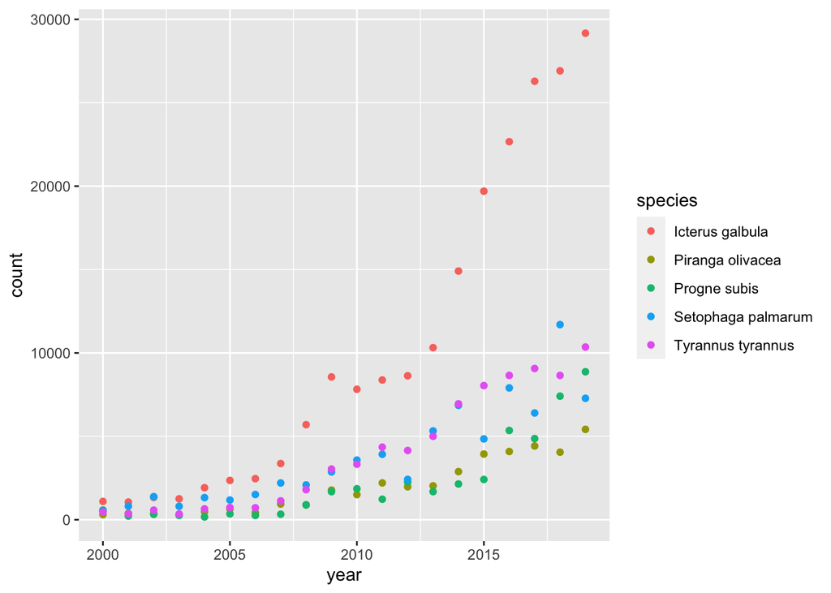

```r
dat <- readRDS("massbird.data.RDS")
dat%>%
  group_by(year,species)%>%
  summarise(count=sum(individualCount,na.rm = T))%>%
  ggplot(aes(x=year,y=count,col=species))+geom_point()
```

We successfully loaded the species occurrence data in from GBIF’s API, and used this graph to visualize the data we have. The graph above allows us to see the amount of data we have, with the dependency of count of species data on the year in the time range requested (Between April and May in 2000-2019).

```r
#We set this code chunk to cache=TRUE, because the code took a significant amount of time to run, and we wanted to prevent having to run it over and over. Instead, the cache remembers the code unless we make a change!
options(noaakey = "GPNjfBVglHVujABdiAesXngwmPtvTiGU")
sts <- c(
  "GHCND:USW00013894", #Mobile, AL 2k away about 10 days away @200 km/day
  "GHCND:USW00013881", #Charlotte, NC 1000 km away about 6 days away @200 km/day
  "GHCND:USW00014739" #Boston
)
sta.d <- bind_rows(#bind the rows
  lapply(sts,function(x) ncdc_stations(stationid = x)$data))%>%
  mutate(usmap_transform(.,input_names = c("longitude","latitude"),output_names = c("longitude.1", "latitude.1")))%>% #join transformation of lat/long for projection with usmap
  mutate(name=str_sub(name, -5,-4))%>% #simplify the name column, grab just the state
  mutate(migr.day=c(10,5,0))%>% #so we can look at wind speed 0, 5 or 10 days before arrive in boston
  separate(id,into = c("station.type","id")) #need to cut station type out from station id number
```

dangling pipe here, makes chunk unrunnable. Removed

```r
grade <- 150
grade <- grade-2
```

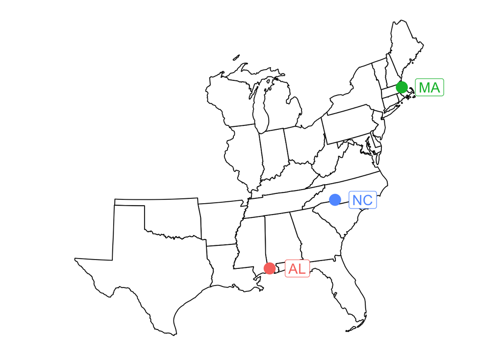

```r
plot_usmap(
  include = c(.northeast_region,.south_region,.east_north_central)
)+geom_point(data=sta.d,aes(x=longitude.1,y=latitude.1,col=name),size=5)+geom_label(data=sta.d,aes(x=longitude.1,y=latitude.1,col=name,label=name),size=5,nudge_x = 1e6*0.25)+theme(legend.position = "none")
```

The map above shows the three locations from which we are collecting weather data as a visual representation of the distance between the stations.

```r
#We set this code chunk to cache=TRUE, because the code took a significant amount of time to run, and we wanted to prevent having to run it over and over. Instead, the cache remembers the code unless we make a change!
weather.d <- meteo_pull_monitors(sta.d$id,date_min = "2000-01-01")
```

```
## using cached file: ~/Library/Caches/R/noaa_ghcnd/USW00013894.dly
```

```
## date created (size, mb): 2022-09-07 15:21:38 (7.831)
```

```
## file min/max dates: 1948-01-01 / 2022-09-30
```

```
## using cached file: ~/Library/Caches/R/noaa_ghcnd/USW00013881.dly
```

```
## date created (size, mb): 2022-09-07 15:21:49 (8.421)
```

```
## file min/max dates: 1939-07-01 / 2022-09-30
```

```
## using cached file: ~/Library/Caches/R/noaa_ghcnd/USW00014739.dly
```

```
## date created (size, mb): 2022-09-07 15:22:00 (9.255)
```

```
## file min/max dates: 1936-01-01 / 2022-09-30
```

```r
tot.dat<- dat%>%
  group_by(year)%>%
  mutate(date=as.Date(paste0(year,"-",month,"-",day)),
         j.day=julian(date,origin=as.Date(paste0(unique(year),"-01-01")))
  )%>%
  group_by(species,year,j.day,date)%>%
  summarise(day.tot=sum(individualCount,na.rm=T))%>%
  group_by(species,year)%>%
  mutate(prop=cumsum(day.tot/sum(day.tot,na.rm = T)))%>%
  filter(year>1999)
```

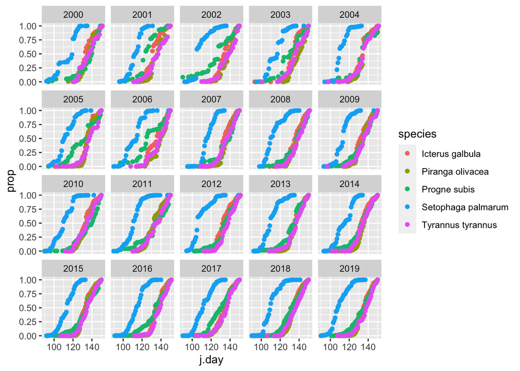

```r
tot.dat%>%
  ggplot(aes(j.day,prop,color=species))+geom_point()+facet_wrap(year~.)
```

The above graph shows the arrival of each of the species we chose during the period of 2000 through 2019. It’s filtered for the months of April and May as well. To analyze this data, species used to categorized the data and logistic models modeled arrival data and estimated the arrival function.

```r
weather.d <- weather.d%>%
  mutate(year=as.integer(str_sub(date,1,4)), #add year
         date=as.Date(date))%>%
  group_by(year)%>% #group by year so we can compute julian day
 mutate(j.day=julian(date,origin=as.Date(paste0(unique(year),"-01-01"))), #add julian day
  date2=date,
  wdir.rad=(180-abs(wdf2-180))*pi/180, #radians so we can use a trig function to compute wind vector, scale degrees first to 180 scale to 2x pi and subtract from 180 (wind comes out of a direction)
  wvec=cos(wdir.rad)*-1*awnd # we want a negative value for positive value for 2x pi
  )%>% #store day in new column
  dplyr::select(id,year,date2,j.day,tmin,tmax,wvec)%>% #select the rows we need
  left_join(sta.d%>%select(id,name,migr.day))%>% #add the station id info (ie. name)
  mutate(j.day=j.day+migr.day)#make j.day ahead of BOS according to the migration days away so we can join weather along path
#Progne subis or The Purple Martin
ps<- dat%>%
  filter(species=="Progne subis")%>%
  group_by(year)%>%
  mutate(date=as.Date(paste0(year,"-",month,"-",day)),
         j.day=julian(date,origin=as.Date(paste0(unique(year),"-01-01")))
  )%>%
  group_by(species,year,j.day,date)%>%
  summarise(day.tot=sum(individualCount,na.rm=T))%>%
  group_by(species,year)%>%
  mutate(prop=cumsum(day.tot/sum(day.tot,na.rm = T)))%>%
  filter(year>1999)
```

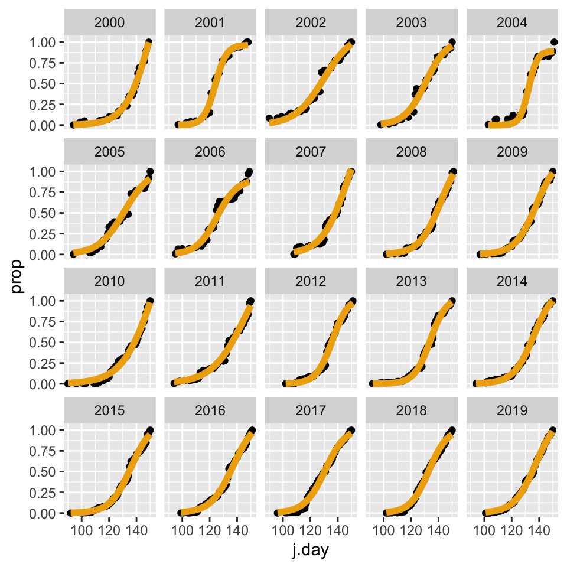

Progne subis or The Purple Martin

```r
ps.pred <- ps%>%
  group_by(year)%>%
  summarize(
    pred=predict(nls(prop~SSlogis(j.day,Asym, xmid, scal)),newdata=data.frame(j.day=min(j.day):max(j.day))),#predict the logistic curve for each species
    j.day=min(j.day):max(j.day),
  )%>%
  left_join(ps%>%dplyr::select(j.day,date)) ## add date back to tibble
ps%>%
  ggplot(aes(j.day,prop))+geom_point(aes=0.3)+geom_line(data=ps.pred,aes(x=j.day,y=pred),col="darkgoldenrod2",size=2)+facet_wrap(year~.)
```

```r
#Piranga olivacea or The Scarlet Tanager
st<- dat%>%
  filter(species=="Piranga olivacea")%>%
  group_by(year)%>%
  mutate(date=as.Date(paste0(year,"-",month,"-",day)),
         j.day=julian(date,origin=as.Date(paste0(unique(year),"-01-01")))
  )%>%
  group_by(species,year,j.day,date)%>%
  summarise(day.tot=sum(individualCount,na.rm=T))%>%
  group_by(species,year)%>%
  mutate(prop=cumsum(day.tot/sum(day.tot,na.rm = T)))%>%
  filter(year>1999)
```

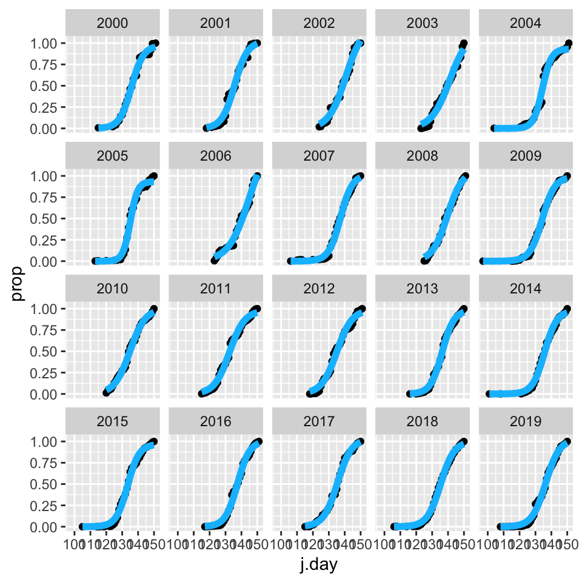

The Scarlet Tanager

```r
st.pred <- st%>%
  group_by(year)%>%
  summarize(
    pred=predict(nls(prop~SSlogis(j.day,Asym, xmid, scal)),newdata=data.frame(j.day=min(j.day):max(j.day))),#predict the logistic curve for each species
    j.day=min(j.day):max(j.day),
  )%>%
  left_join(st%>%dplyr::select(j.day,date)) ## add date back to tibble
st%>%
  ggplot(aes(j.day,prop))+geom_point(aes=0.3)+geom_line(data=st.pred,aes(x=j.day,y=pred),col="deepskyblue1",size=2)+facet_wrap(year~.)
```

```r
#Setophaga palmarum or The Palm Warbler
pw<- dat%>%
  filter(species=="Setophaga palmarum")%>%
  group_by(year)%>%
  mutate(date=as.Date(paste0(year,"-",month,"-",day)),
         j.day=julian(date,origin=as.Date(paste0(unique(year),"-01-01")))
  )%>%
  group_by(species,year,j.day,date)%>%
  summarise(day.tot=sum(individualCount,na.rm=T))%>%
  group_by(species,year)%>%
  mutate(prop=cumsum(day.tot/sum(day.tot,na.rm = T)))%>%
  filter(year>1999)
```

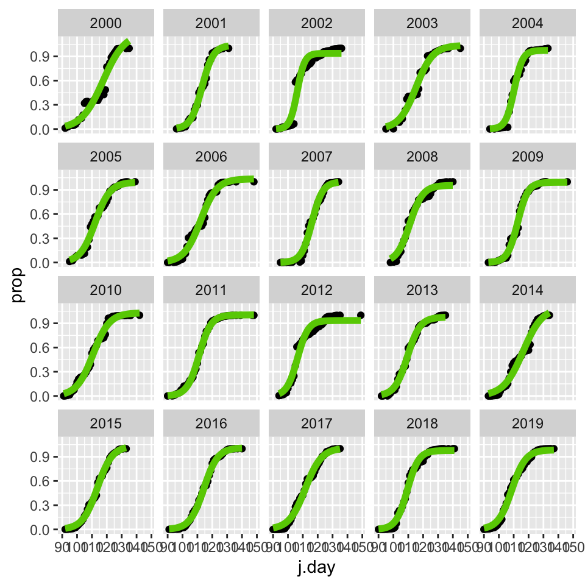

The Palm Warbler

```r
pw.pred <- pw%>%
  group_by(year)%>%
  summarize(
    pred=predict(nls(prop~SSlogis(j.day,Asym, xmid, scal)),newdata=data.frame(j.day=min(j.day):max(j.day))),#predict the logistic curve for each species
    j.day=min(j.day):max(j.day),
  )%>%
  left_join(pw%>%dplyr::select(j.day,date)) ## add date back to tibble
pw%>%
  ggplot(aes(j.day,prop))+geom_point(aes=0.3)+geom_line(data=pw.pred,aes(x=j.day,y=pred),col="chartreuse3",size=2)+facet_wrap(year~.)
```

```r
#Icterus galbula or The Baltimore Oriole
bo<- dat%>%
  filter(species=="Icterus galbula")%>%
  group_by(year)%>%
  mutate(date=as.Date(paste0(year,"-",month,"-",day)),
         j.day=julian(date,origin=as.Date(paste0(unique(year),"-01-01")))
  )%>%
  group_by(species,year,j.day,date)%>%
  summarise(day.tot=sum(individualCount,na.rm=T))%>%
  group_by(species,year)%>%
  mutate(prop=cumsum(day.tot/sum(day.tot,na.rm = T)))%>%
  filter(year>1999)
```

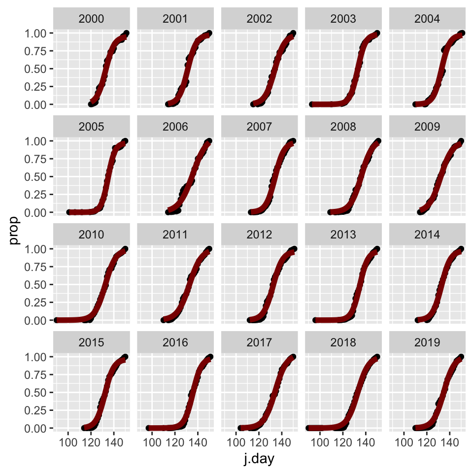

The Baltimore Oriole

```r
bo.pred <- bo%>%
  group_by(year)%>%
  summarize(
    pred=predict(nls(prop~SSlogis(j.day,Asym, xmid, scal)),newdata=data.frame(j.day=min(j.day):max(j.day))),#predict the logistic curve for each species
    j.day=min(j.day):max(j.day),
  )%>%
  left_join(bo%>%dplyr::select(j.day,date)) ## add date back to tibble
bo%>%
  ggplot(aes(j.day,prop))+geom_point(aes=0.3)+geom_line(data=bo.pred,aes(x=j.day,y=pred),col="darkred",size=2)+facet_wrap(year~.)
```

```r
#Tyrannus tyrannus or The Eastern Kingbird
ek<- dat%>%
  filter(species=="Megaceryle alcyon")%>%
  group_by(year)%>%
  mutate(date=as.Date(paste0(year,"-",month,"-",day)),
         j.day=julian(date,origin=as.Date(paste0(unique(year),"-01-01")))
  )%>%
  group_by(species,year,j.day,date)%>%
  summarise(day.tot=sum(individualCount,na.rm=T))%>%
  group_by(species,year)%>%
  mutate(prop=cumsum(day.tot/sum(day.tot,na.rm = T)))%>%
  filter(year>1999)
ek.pred <- ek%>%
  group_by(year)%>%
  summarize(
    pred=predict(nls(prop~SSlogis(j.day,Asym, xmid, scal)),newdata=data.frame(j.day=min(j.day):max(j.day))),#predict the logistic curve for each species
    j.day=min(j.day):max(j.day),
  )%>%
  left_join(ek%>%dplyr::select(j.day,date)) ## add date back to tibble
ek%>%
  ggplot(aes(j.day,prop))+geom_point(aes=0.3)+geom_line(data=ek.pred,aes(x=j.day,y=pred),col="coral1",size=2)+facet_wrap(year~.)
```

umm, this is not the sci name for eastern kingbird (Tyrannus tyrannus), so chunk results in finding no rows after first filter operation.

```r
grade <- 150
grade <- grade-2
```

redone here . . .

```r
#Tyrannus tyrannus or The Eastern Kingbird
ek<- dat%>%
  filter(species=="Tyrannus tyrannus")%>%
  group_by(year)%>%
  mutate(date=as.Date(paste0(year,"-",month,"-",day)),
         j.day=julian(date,origin=as.Date(paste0(unique(year),"-01-01")))
  )%>%
  group_by(species,year,j.day,date)%>%
  summarise(day.tot=sum(individualCount,na.rm=T))%>%
  group_by(species,year)%>%
  mutate(prop=cumsum(day.tot/sum(day.tot,na.rm = T)))%>%
  filter(year>1999)
```

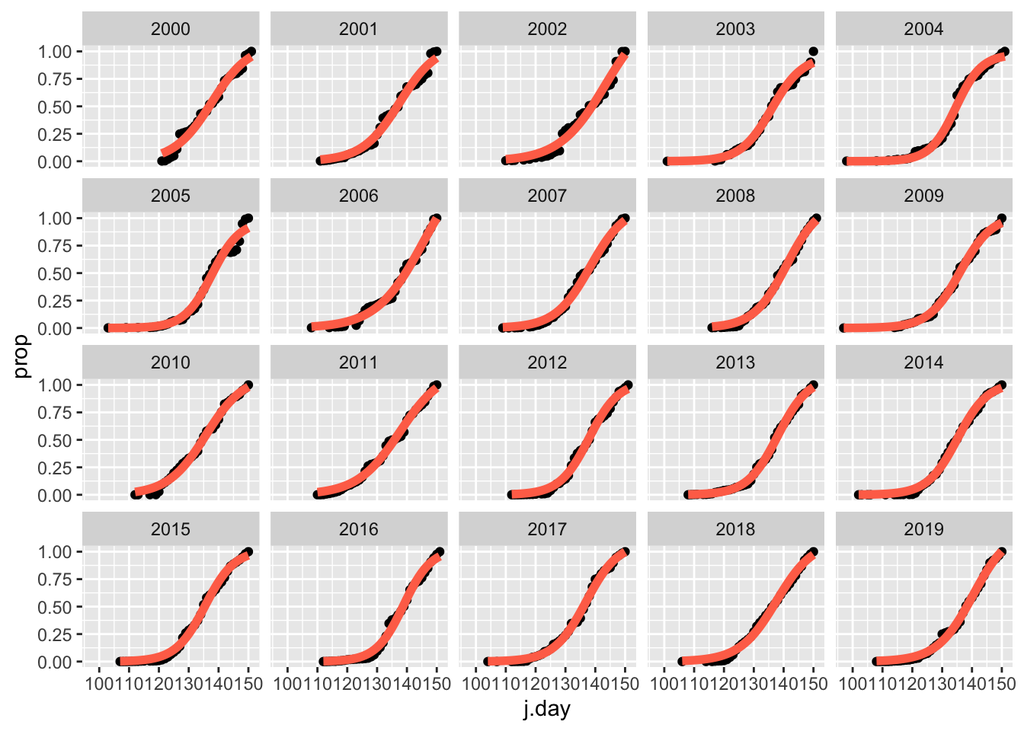

The Eastern Kingbird

```r
ek.pred <- ek%>%
  group_by(year)%>%
  summarize(
    pred=predict(nls(prop~SSlogis(j.day,Asym, xmid, scal)),newdata=data.frame(j.day=min(j.day):max(j.day))),#predict the logistic curve for each species
    j.day=min(j.day):max(j.day),
  )%>%
  left_join(ek%>%dplyr::select(j.day,date)) ## add date back to tibble
ek%>%
  ggplot(aes(j.day,prop))+geom_point(aes=0.3)+geom_line(data=ek.pred,aes(x=j.day,y=pred),col="coral1",size=2)+facet_wrap(year~.)
```

But the major issue with the logistic model chunks is that you didn’t need to eexcute a chunk for each species. You already did this above, all the species at once. From there, you could have move on to this.

```r
all.pred <- tot.dat%>%
  group_by(species,year)%>%
  summarize(
    pred=predict(nls(prop~SSlogis(j.day,Asym, xmid, scal)),newdata=data.frame(j.day=min(j.day):max(j.day))),#predict the logistic curve for each species
    j.day=min(j.day):max(j.day),
  )%>%
  left_join(tot.dat%>%dplyr::select(species,j.day,date)) ## add date back to tibble
grade <- grade-5
```

After looking at the logistic models of each of the species, our group came to the conclusion that species arrive periodically in the months. Some species arrive earlier, while other species arrive later. This accounts for the effect the temperature *within* the year has, but now we need to look at the effect that years have had over time (i.e. how changing overall temperatures over the years have effected the time of arrival of these species)

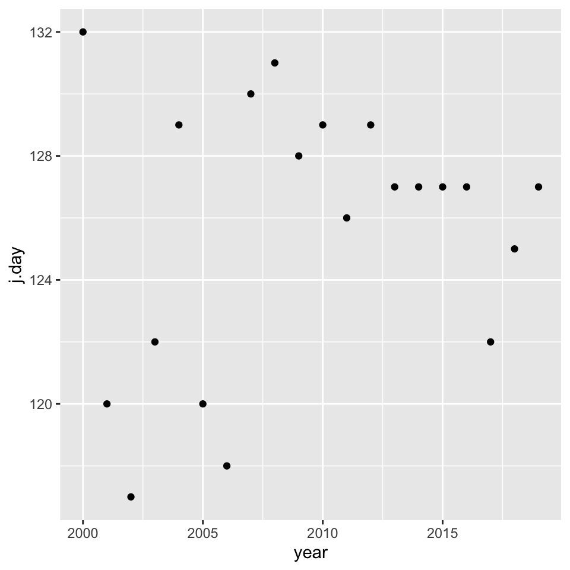

The Purple Martin

```r
#Progne subis or The Purple Martin
ps.arrive.date <-ps.pred%>%
  group_by(year)%>%
  filter(j.day==j.day[which.min(abs(pred-0.25))])
ps.arrive.date%>%
  ggplot(aes(year,j.day))+geom_point()
```

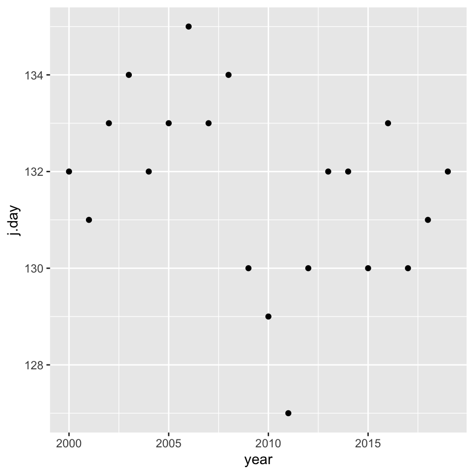

The Scarlet Tanager

```r
#Piranga olivacea or The Scarlet Tanager
st.arrive.date <-st.pred%>%
  group_by(year)%>%
  filter(j.day==j.day[which.min(abs(pred-0.25))])
st.arrive.date%>%
  ggplot(aes(year,j.day))+geom_point()
```

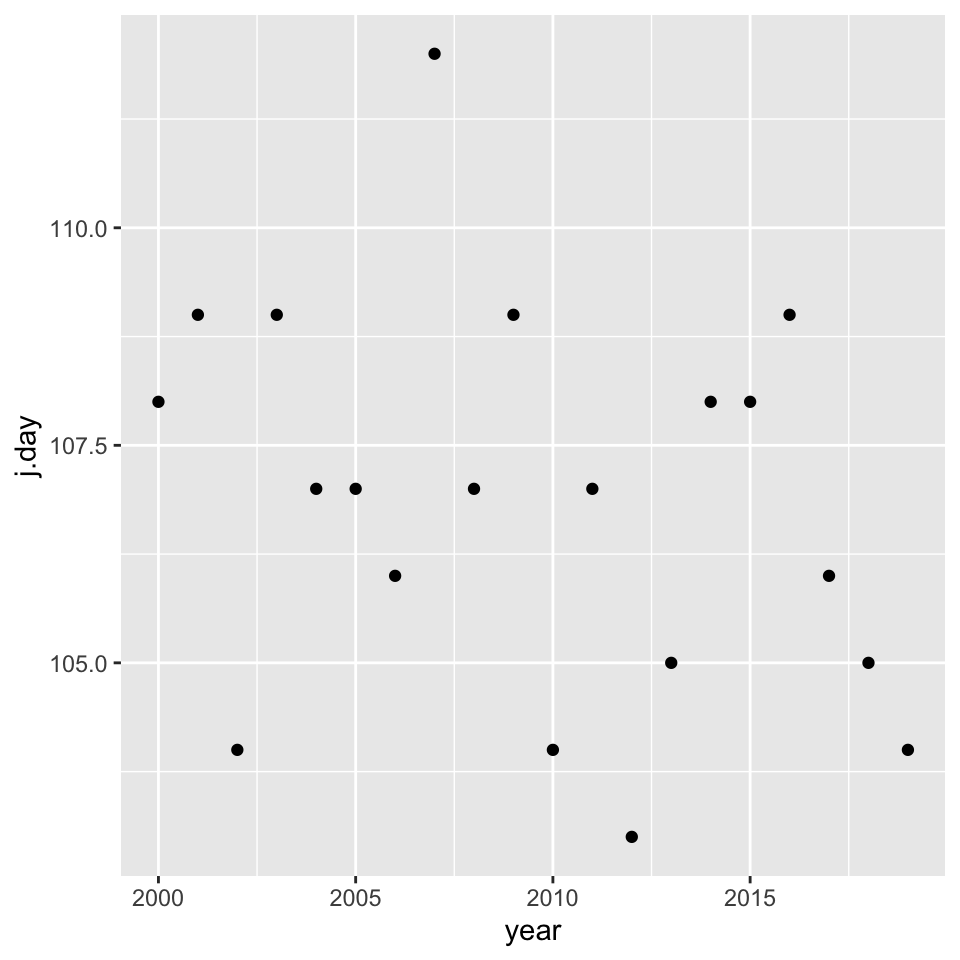

The Palm Warbler

```r
#Setophaga palmarum or The Palm Warbler
pw.arrive.date <-pw.pred%>%
  group_by(year)%>%
  filter(j.day==j.day[which.min(abs(pred-0.25))])
pw.arrive.date%>%
  ggplot(aes(year,j.day))+geom_point()
```

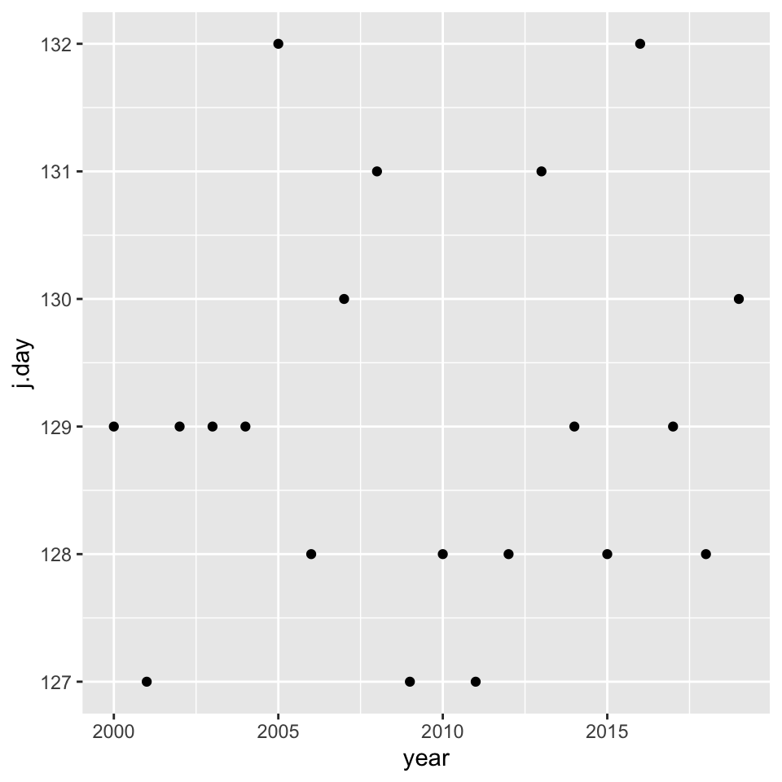

The Baltimore Oriole

```r
#Icterus galbula or The Baltimore Oriole
bo.arrive.date <-bo.pred%>%
  group_by(year)%>%
  filter(j.day==j.day[which.min(abs(pred-0.25))])
bo.arrive.date%>%
  ggplot(aes(year,j.day))+geom_point()
```

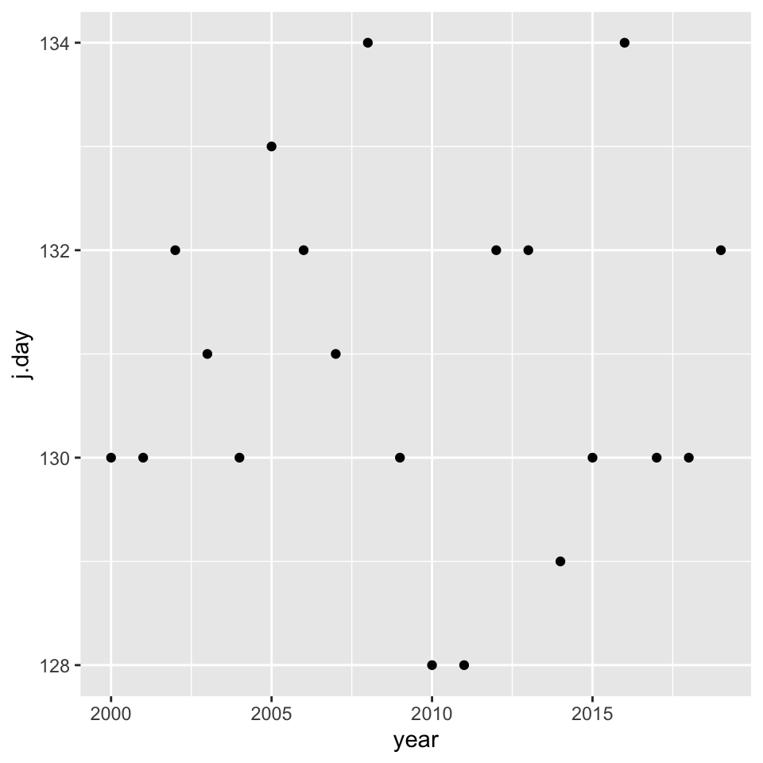

The Eastern Kingbird

```r
#Tyrannus tyrannus or The Eastern Kingbird
ek.arrive.date <-ek.pred%>%
  group_by(year)%>%
  filter(j.day==j.day[which.min(abs(pred-0.25))])
ek.arrive.date%>%
  ggplot(aes(year,j.day))+geom_point()
```

For each of the species we analyzed, the results that we found from this data do not show much of a pattern between the arrival date from *year to year*, so we will determine how weather might have an effect on the migration pattern of the species annually.